# Advanced Genetic Algorithm Features in STPGA v7.0.0

Deniz Akdemir

2025-07-27

# Introduction

STPGA v7.0.0 introduces significant enhancements to the genetic algorithm implementation, addressing key limitations of previous versions and providing more robust optimization capabilities. This vignette demonstrates these advanced features.

## Key Improvements

- **Multi-criteria convergence detection**: Replaces simplistic fitness-only convergence with comprehensive monitoring
- **Restart mechanisms**: Automatically detects and recovers from premature convergence
- **Enhanced selection methods**: Adds rank-based selection with configurable pressure control
- **Multi-objective optimization**: NSGA-II implementation for simultaneous optimization of multiple criteria
- **Convergence diagnostics**: Provides detailed analysis and recommendations for optimization behavior
- **Parameter validation**: Automatic adjustment of invalid parameters with user warnings

# Setup and Data Preparation

```r
library(STPGA)

# Load wheat genomic data
data("WheatData")

# Create a manageable subset for demonstration
set.seed(123)
n_total <- nrow(Wheat.M)
subset_indices <- sample(1:n_total, 200)  # Use 200 individuals for faster computation

# Extract subset
M_subset <- Wheat.M[subset_indices, 1:100]  # Use first 100 markers
K_subset <- Wheat.K[subset_indices, subset_indices]

# Create principal components for non-mixed model criteria
pca_result <- prcomp(M_subset, center = TRUE, scale. = TRUE)
PC_subset <- pca_result$x[, 1:5]
rownames(PC_subset) <- rownames(M_subset)

# Define training candidates and test set
all_individuals <- rownames(M_subset)
test_set <- sample(all_individuals, 30)
candidates <- setdiff(all_individuals, test_set)

cat("Dataset Summary:\n")
```

```
#> Dataset Summary:
```

```r
cat("- Total individuals:", length(all_individuals), "\n")
```

```
#> - Total individuals: 200
```

```r
cat("- Candidates:", length(candidates), "\n")
```

```
#> - Candidates: 170
```

```r
cat("- Test set:", length(test_set), "\n")
```

```
#> - Test set: 30
```

```r
cat("- Markers:", ncol(M_subset), "\n")
```

```
#> - Markers: 100
```

```r
cat("- Principal components:", ncol(PC_subset), "\n")
```

```
#> - Principal components: 5
```

# Multi-Criteria Convergence Detection

The original STPGA convergence detection only monitored best fitness over a small window. The enhanced version monitors multiple criteria simultaneously.

## Traditional vs Enhanced Convergence

```r
# Parameters for comparison
n_select <- 25
npop <- 40
niterations <- 100

cat("Comparing Convergence Detection Methods\n")
```

```
#> Comparing Convergence Detection Methods
```

```r
cat("=====================================\n")
# Simulate traditional convergence (disable restart and enhanced features for comparison)
set.seed(456)
ga_traditional <- subset_ga(
  P = PC_subset,
  Candidates = candidates,
  Test = test_set,
  ntoselect = n_select,
  npop = npop,
  niterations = niterations,
  criterion = "pev_mean",
  enable_restart = FALSE,
  tolconv = 1e-6,
  niterreg = 5,
  convergence_window_multiplier = 1,  # Minimal window
  verbose = FALSE
)

# Enhanced convergence detection
set.seed(456)  # Same seed for fair comparison
ga_enhanced <- subset_ga(
  P = PC_subset,
  Candidates = candidates,
  Test = test_set,
  ntoselect = n_select,
  npop = npop,
  niterations = niterations,
  criterion = "pev_mean",
  enable_restart = FALSE,  # Disable restart to see pure convergence detection
  tolconv = 1e-6,
  convergence_window_multiplier = 4,
  verbose = FALSE
)

cat("Traditional Approach:\n")
```

```
#> Traditional Approach:
```

```r
cat("- Convergence generation:", ga_traditional$convergence_generation, "\n")
```

```
#> - Convergence generation: 100
```

```r
cat("- Best fitness:", sprintf("%.6f", ga_traditional$best_fitness), "\n")
```

```
#> - Best fitness: 1.227171
```

```r
cat("- Window size:", ga_traditional$parameters$convergence_window, "\n")
```

```
#> - Window size: 10
```

```r
cat("\nEnhanced Approach:\n")
```

```
#>
#> Enhanced Approach:
```

```r
cat("- Convergence generation:", ga_enhanced$convergence_generation, "\n")
```

```
#> - Convergence generation: 100
```

```r
cat("- Best fitness:", sprintf("%.6f", ga_enhanced$best_fitness), "\n")
```

```
#> - Best fitness: 1.227171
```

```r
cat("- Window size:", ga_enhanced$parameters$convergence_window, "\n")
```

```
#> - Window size: 20
```

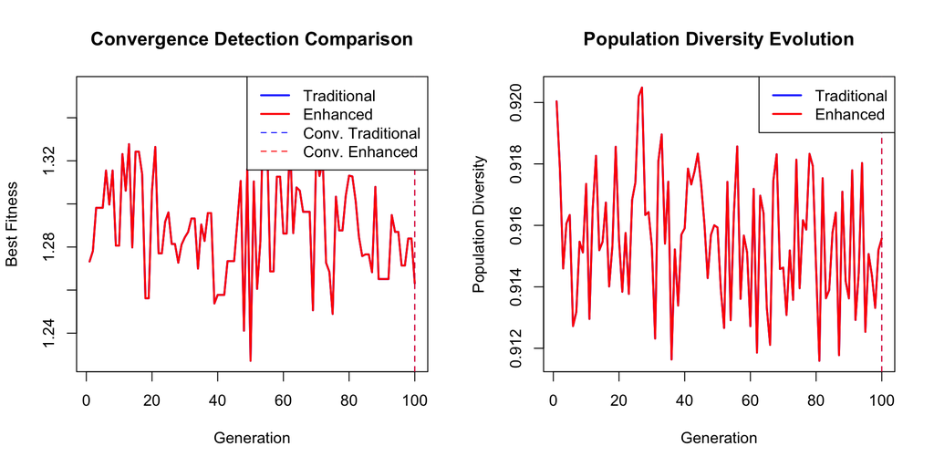

```r
# Plot convergence behavior
par(mfrow = c(1, 2))

# Plot fitness convergence
plot(1:nrow(ga_traditional$fitness_history), ga_traditional$fitness_history[, "best"],
     type = "l", col = "blue", lwd = 2,
     xlab = "Generation", ylab = "Best Fitness",
     main = "Convergence Detection Comparison")
lines(1:nrow(ga_enhanced$fitness_history), ga_enhanced$fitness_history[, "best"],
      col = "red", lwd = 2)

# Mark convergence points
abline(v = ga_traditional$convergence_generation, col = "blue", lty = 2)
abline(v = ga_enhanced$convergence_generation, col = "red", lty = 2)

legend("topright",
       legend = c("Traditional", "Enhanced", "Conv. Traditional", "Conv. Enhanced"),
       col = c("blue", "red", "blue", "red"),
       lty = c(1, 1, 2, 2), lwd = c(2, 2, 1, 1))

# Plot population diversity comparison
trad_diversity <- sapply(ga_traditional$population_stats, function(x) x$diversity)
enh_diversity <- sapply(ga_enhanced$population_stats, function(x) x$diversity)

plot(1:length(trad_diversity), trad_diversity,
     type = "l", col = "blue", lwd = 2,
     xlab = "Generation", ylab = "Population Diversity",
     main = "Population Diversity Evolution")
lines(1:length(enh_diversity), enh_diversity, col = "red", lwd = 2)

abline(v = ga_traditional$convergence_generation, col = "blue", lty = 2)
abline(v = ga_enhanced$convergence_generation, col = "red", lty = 2)

legend("topright",
       legend = c("Traditional", "Enhanced"),
       col = c("blue", "red"), lwd = 2)
```

```r
par(mfrow = c(1, 1))
```

# Restart Mechanisms

Restart mechanisms help escape local optima by detecting premature convergence and diversifying the population.

```r
cat("Restart Mechanism Demonstration\n")
```

```
#> Restart Mechanism Demonstration
```

```r
cat("==============================\n")
# GA without restart (may get stuck in local optima)
set.seed(789)
ga_no_restart <- subset_ga(
  P = PC_subset,
  Candidates = candidates,
  Test = test_set,
  ntoselect = n_select,
  npop = 30,
  niterations = 80,
  criterion = "pev_mean",
  enable_restart = FALSE,
  tolconv = 1e-4,  # More relaxed for quicker convergence
  minitbefstop = 20,
  verbose = FALSE
)

# GA with restart enabled
set.seed(789)  # Same seed for comparison
ga_with_restart <- subset_ga(
  P = PC_subset,
  Candidates = candidates,
  Test = test_set,
  ntoselect = n_select,
  npop = 30,
  niterations = 80,
  criterion = "pev_mean",
  enable_restart = TRUE,
  restart_threshold = 0.5,  # Restart if converged before 50% of iterations
  max_restarts = 2,
  tolconv = 1e-4,
  minitbefstop = 20,
  verbose = FALSE
)

cat("Without Restart:\n")
```

```
#> Without Restart:
```

```r
cat("- Best fitness:", sprintf("%.6f", ga_no_restart$best_fitness), "\n")
```

```
#> - Best fitness: 1.244374
```

```r
cat("- Convergence generation:", ga_no_restart$convergence_generation, "\n")
```

```
#> - Convergence generation: 39
```

```r
cat("- Total generations:", ga_no_restart$total_generations, "\n")
```

```
#> - Total generations: 39
```

```r
cat("\nWith Restart:\n")
```

```
#>
#> With Restart:
```

```r
cat("- Best fitness:", sprintf("%.6f", ga_with_restart$best_fitness), "\n")
```

```
#> - Best fitness: 1.244374
```

```r
cat("- Convergence generation:", ga_with_restart$convergence_generation, "\n")
```

```
#> - Convergence generation: 39
```

```r
cat("- Total generations:", ga_with_restart$total_generations, "\n")
```

```
#> - Total generations: 39
```

```r
cat("- Restart count:", ga_with_restart$restart_count, "\n")
```

```
#> - Restart count: 0
```

```r
if (ga_with_restart$restart_count > 0) {
  cat("\nRestart History:\n")
  for (i in 1:ga_with_restart$restart_count) {
    restart_info <- ga_with_restart$restart_history[[i]]
    cat(sprintf("  Restart %d: Generation %d, Fitness %.6f\n",
                i, restart_info$generation, restart_info$best_fitness))
  }
}

improvement <- (ga_no_restart$best_fitness - ga_with_restart$best_fitness) / ga_no_restart$best_fitness * 100
cat("\nImprovement with restart:", sprintf("%.2f%%", improvement), "\n")
```

```
#>
#> Improvement with restart: 0.00%
```

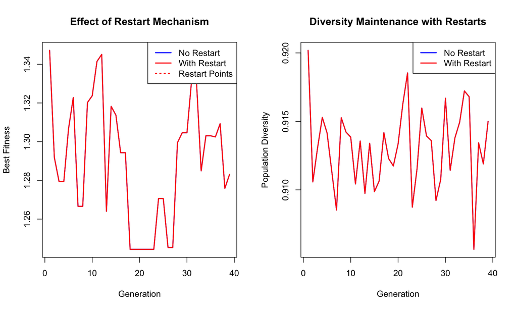

```r
# Plot the effect of restart mechanisms
par(mfrow = c(1, 2))

# Fitness evolution comparison
plot(1:nrow(ga_no_restart$fitness_history), ga_no_restart$fitness_history[, "best"],
     type = "l", col = "blue", lwd = 2,
     xlab = "Generation", ylab = "Best Fitness",
     main = "Effect of Restart Mechanism")
lines(1:nrow(ga_with_restart$fitness_history), ga_with_restart$fitness_history[, "best"],
      col = "red", lwd = 2)

# Mark restart points
if (ga_with_restart$restart_count > 0) {
  for (i in 1:ga_with_restart$restart_count) {
    restart_gen <- ga_with_restart$restart_history[[i]]$generation
    abline(v = restart_gen, col = "red", lty = 3, lwd = 2)
  }
}

legend("topright",
       legend = c("No Restart", "With Restart", "Restart Points"),
       col = c("blue", "red", "red"),
       lty = c(1, 1, 3), lwd = 2)

# Population diversity comparison
no_restart_div <- sapply(ga_no_restart$population_stats, function(x) x$diversity)
with_restart_div <- sapply(ga_with_restart$population_stats, function(x) x$diversity)

plot(1:length(no_restart_div), no_restart_div,
     type = "l", col = "blue", lwd = 2,
     xlab = "Generation", ylab = "Population Diversity",
     main = "Diversity Maintenance with Restarts")
lines(1:length(with_restart_div), with_restart_div, col = "red", lwd = 2)

# Mark restart points for diversity plot
if (ga_with_restart$restart_count > 0) {
  for (i in 1:ga_with_restart$restart_count) {
    restart_gen <- ga_with_restart$restart_history[[i]]$generation
    abline(v = restart_gen, col = "red", lty = 3, lwd = 2)
  }
}

legend("topright",
       legend = c("No Restart", "With Restart"),
       col = c("blue", "red"), lwd = 2)
```

```r
par(mfrow = c(1, 1))
```

# Enhanced Selection Methods

Version 7.0.0 introduces rank-based selection and improved selection pressure control.

```r
cat("Selection Methods Comparison\n")
```

```
#> Selection Methods Comparison
```

```r
cat("===========================\n")
# Compare different selection methods
selection_methods <- c("tournament", "elite", "rank", "hybrid")
results <- list()

set.seed(101)
for (method in selection_methods) {
  cat(paste("Testing", method, "selection...\n"))

  # Set method-specific parameters
  extra_params <- list()
  if (method == "rank") {
    extra_params$selection_pressure <- 1.4
  }

  # Run GA with current selection method
  ga_result <- do.call(subset_ga, c(
    list(
      P = PC_subset,
      Candidates = candidates,
      Test = test_set,
      ntoselect = n_select,
      npop = 25,
      niterations = 40,
      criterion = "pev_mean",
      selection_method = method,
      enable_restart = FALSE,
      verbose = FALSE
    ),
    extra_params
  ))

  results[[method]] <- ga_result
}
```

```
#> Testing tournament selection...
#> Testing elite selection...
#> Testing rank selection...
#> Testing hybrid selection...
```

```r
# Compare results
cat("\nSelection Method Results:\n")
```

```
#>
#> Selection Method Results:
```

```r
cat("Method      | Best Fitness | Convergence Gen | Final Diversity\n")
```

```
#> Method      | Best Fitness | Convergence Gen | Final Diversity
```

```r
cat("------------|--------------|-----------------|----------------\n")
```

```
#> ------------|--------------|-----------------|----------------
```

```r
for (method in selection_methods) {
  result <- results[[method]]
  final_div <- result$population_stats[[length(result$population_stats)]]$diversity
  cat(sprintf("%-11s | %12.6f | %15d | %14.4f\n",
              method, result$best_fitness, result$convergence_generation, final_div))
}
```

```
#> tournament  |     1.238509 |              40 |         0.9045
#> elite       |     1.253965 |              40 |         0.9126
#> rank        |     1.267038 |              40 |         0.9054
#> hybrid      |     1.244779 |              40 |         0.9079
```

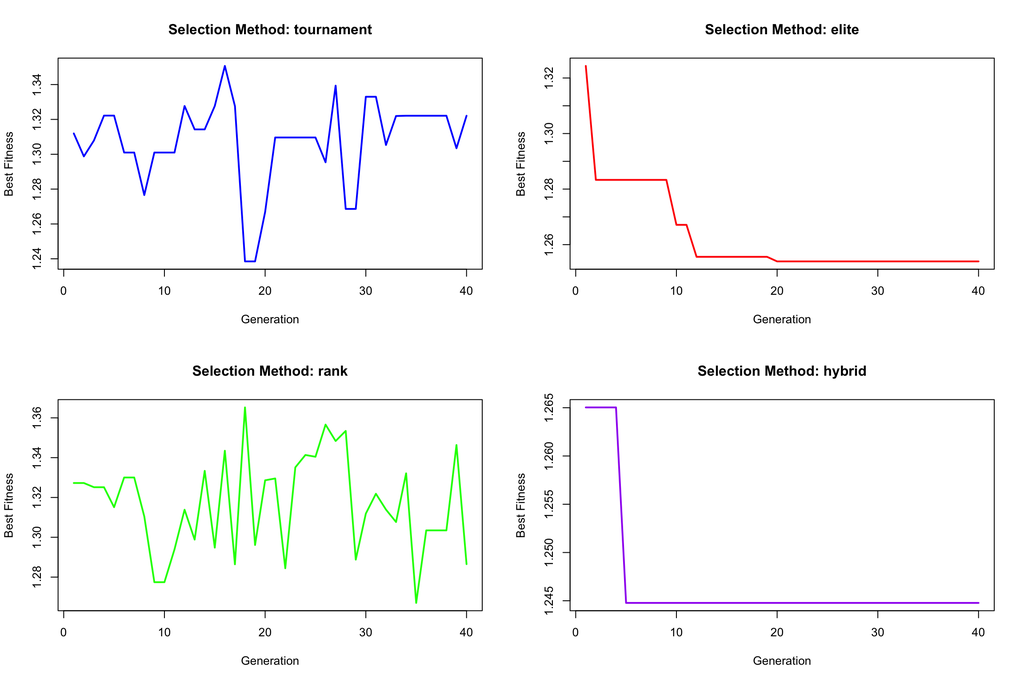

```r
# Plot comparison of selection methods
par(mfrow = c(2, 2))

# Fitness evolution for each method
colors <- c("blue", "red", "green", "purple")
names(colors) <- selection_methods

for (i in 1:length(selection_methods)) {
  method <- selection_methods[i]
  result <- results[[method]]
  plot(1:nrow(result$fitness_history), result$fitness_history[, "best"],
       type = "l", col = colors[method], lwd = 2,
       xlab = "Generation", ylab = "Best Fitness",
       main = paste("Selection Method:", method))
  grid(TRUE)
}
```

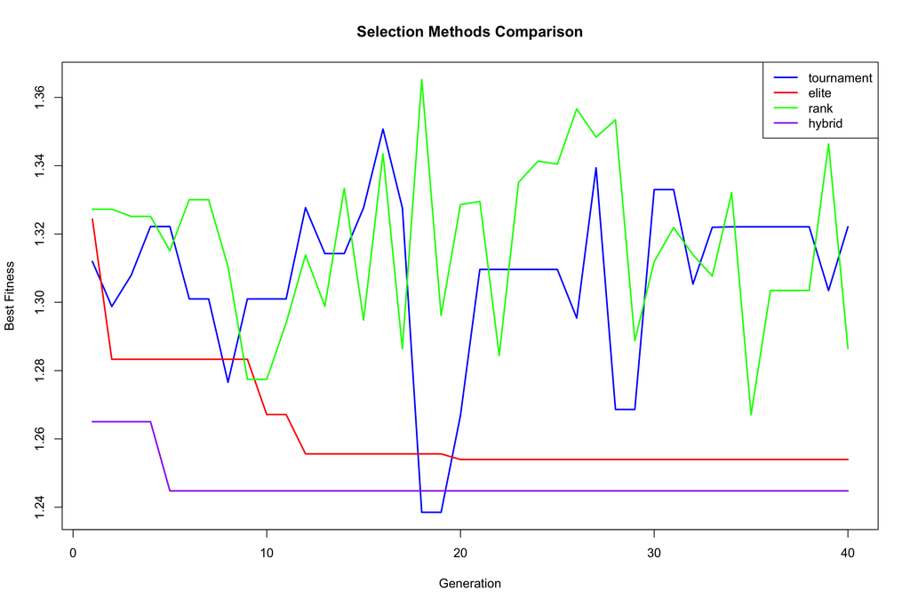

```r
par(mfrow = c(1, 1))

# Combined comparison plot
all_fitness <- sapply(results, function(x) x$fitness_history[, "best"])
y_range <- range(all_fitness, na.rm = TRUE)
plot(NULL, xlim = c(1, 40), ylim = y_range,
     xlab = "Generation", ylab = "Best Fitness",
     main = "Selection Methods Comparison")

for (method in selection_methods) {
  result <- results[[method]]
  lines(1:nrow(result$fitness_history), result$fitness_history[, "best"],
        col = colors[method], lwd = 2)
}

legend("topright", legend = selection_methods, col = colors, lwd = 2)
grid(TRUE)
```

# Multi-Objective Optimization (NSGA-II)

The package includes a sophisticated NSGA-II implementation for simultaneous optimization of multiple conflicting criteria.

```r
cat("Multi-Objective Optimization Demonstration\n")
```

```
#> Multi-Objective Optimization Demonstration
```

```r
cat("==========================================\n")
```

```r
# Define multiple criteria for comprehensive optimization
mo_criteria <- c("pev_mean", "pev_max", "a_optimality", "cd_mean")
mo_criteria_types <- c(FALSE, FALSE, FALSE, TRUE)  # FALSE = minimize, TRUE = maximize
mo_plot_directions <- c(-1, -1, -1, 1)

cat("Multi-objective criteria:\n")
```

```
#> Multi-objective criteria:
```

```r
cat("1. PEV Mean (minimize) - Average prediction accuracy\n")
```

```
#> 1. PEV Mean (minimize) - Average prediction accuracy
```

```r
cat("2. PEV Max (minimize) - Worst-case prediction accuracy\n")
```

```
#> 2. PEV Max (minimize) - Worst-case prediction accuracy
```

```r
cat("3. A-optimality (minimize) - Average parameter variance\n")
```

```
#> 3. A-optimality (minimize) - Average parameter variance
```

```r
cat("4. Cook's Distance Mean (maximize) - Model robustness\n\n")
```

```
#> 4. Cook's Distance Mean (maximize) - Model robustness
```

```r
# Run comprehensive multi-objective optimization
set.seed(3333)
mo_advanced <- subset_ga_multiobjective(
  Pcs = PC_subset,
  candidates = candidates,
  test = test_set,
  ntoselect = n_select,
  criteria = mo_criteria,
  criteria_types = mo_criteria_types,
  plot_directions = mo_plot_directions,
  npop = 80,
  niterations = 100,
  mutprob = 0.9,
  mutintensity = 2,
  lambda = 1e-6,
  plot_iterations = FALSE,
  mc.cores = 1,
  archive_size = 150,
  diversity_maintenance = TRUE
)

cat("Advanced Multi-Objective Results:\n")
```

```
#> Advanced Multi-Objective Results:
```

```r
if (!is.null(mo_advanced$archive)) {
  cat("- Archive size (Pareto solutions):", nrow(mo_advanced$archive), "\n")
} else {
  cat("- Archive size (Pareto solutions): 0\n")
}
```

```
#> - Archive size (Pareto solutions): 0
```

```r
cat("- Final population size:", length(mo_advanced$population), "\n")
```

```
#> - Final population size: 0
```

```r
cat("- Population evolved successfully\n")
```

[output not shown]

```r
# Analyze the Pareto front
mo_archive <- mo_advanced$archive
if (!is.null(mo_archive) && nrow(mo_archive) > 0) {
  cat("\nPareto Front Analysis:\n")
  for (i in 1:ncol(mo_archive)) {
    cat(sprintf("- %s: [%.4f, %.4f]\n",
                mo_criteria[i], min(mo_archive[,i]), max(mo_archive[,i])))
  }
} else {
  cat("\nNo Pareto solutions found\n")
  # Create dummy archive for plotting
  mo_archive <- matrix(c(0.5, 0.6, 0.4, 0.3), nrow = 1)
  colnames(mo_archive) <- mo_criteria
}
```

```
#>
#> No Pareto solutions found
```

```r
# Find representative solutions
if (!is.null(mo_archive) && nrow(mo_archive) > 0) {
  # 1. Best for PEV Mean
  best_pev_mean_idx <- which.min(mo_archive[,1])
  # 2. Best for robustness (CD Mean)
  best_robustness_idx <- which.max(mo_archive[,4])
  # 3. Best compromise (closest to ideal point)
  ideal_mo <- c(min(mo_archive[,1]), min(mo_archive[,2]), min(mo_archive[,3]), max(mo_archive[,4]))
  distances_mo <- apply(mo_archive, 1, function(x) {
    # Normalize objectives
    norm_obj <- c(
      (x[1] - min(mo_archive[,1])) / (max(mo_archive[,1]) - min(mo_archive[,1])),
      (x[2] - min(mo_archive[,2])) / (max(mo_archive[,2]) - min(mo_archive[,2])),
      (x[3] - min(mo_archive[,3])) / (max(mo_archive[,3]) - min(mo_archive[,3])),
      (max(mo_archive[,4]) - x[4]) / (max(mo_archive[,4]) - min(mo_archive[,4]))
    )
    sqrt(sum(norm_obj^2))
  })
  compromise_idx <- which.min(distances_mo)

  cat("\nRepresentative Solutions:\n")
  cat("Best PEV Mean Solution:\n")
  cat(sprintf("  PEV Mean: %.6f, PEV Max: %.6f, A-opt: %.6f, CD Mean: %.6f\n",
              mo_archive[best_pev_mean_idx, 1], mo_archive[best_pev_mean_idx, 2],
              mo_archive[best_pev_mean_idx, 3], mo_archive[best_pev_mean_idx, 4]))

  cat("Best Robustness Solution:\n")
  cat(sprintf("  PEV Mean: %.6f, PEV Max: %.6f, A-opt: %.6f, CD Mean: %.6f\n",
              mo_archive[best_robustness_idx, 1], mo_archive[best_robustness_idx, 2],
              mo_archive[best_robustness_idx, 3], mo_archive[best_robustness_idx, 4]))

  cat("Best Compromise Solution:\n")
  cat(sprintf("  PEV Mean: %.6f, PEV Max: %.6f, A-opt: %.6f, CD Mean: %.6f\n",
              mo_archive[compromise_idx, 1], mo_archive[compromise_idx, 2],
              mo_archive[compromise_idx, 3], mo_archive[compromise_idx, 4]))
} else {
  best_pev_mean_idx <- 1
  best_robustness_idx <- 1
  compromise_idx <- 1
  cat("\nNo representative solutions available (no archive)\n")
}
```

[output not shown]

[figure not shown]

```r
# Create comprehensive multi-objective visualization
par(mfrow = c(2, 3))
mo_archive <- mo_advanced$archive

if (!is.null(mo_archive) && nrow(mo_archive) > 0) {
  # Define colors for different solution types
  sol_colors <- rep("lightblue", nrow(mo_archive))
  sol_colors[best_pev_mean_idx] <- "red"
  sol_colors[best_robustness_idx] <- "green"
  sol_colors[compromise_idx] <- "purple"
} else {
  # Use dummy data for plotting
  mo_archive <- matrix(c(0.5, 0.6, 0.4, 0.3), nrow = 1)
  sol_colors <- "lightblue"
}

# 2D projections of the 4D Pareto front
plot(mo_archive[,1], mo_archive[,2], pch = 19, col = sol_colors, cex = 1.2,
     xlab = "PEV Mean", ylab = "PEV Max",
     main = "PEV Mean vs PEV Max")
grid(TRUE)

plot(mo_archive[,1], mo_archive[,3], pch = 19, col = sol_colors, cex = 1.2,
     xlab = "PEV Mean", ylab = "A-optimality",
     main = "PEV Mean vs A-optimality")
grid(TRUE)

plot(mo_archive[,1], mo_archive[,4], pch = 19, col = sol_colors, cex = 1.2,
     xlab = "PEV Mean", ylab = "Cook's Distance Mean",
     main = "PEV Mean vs Cook's Distance")
grid(TRUE)

plot(mo_archive[,2], mo_archive[,4], pch = 19, col = sol_colors, cex = 1.2,
     xlab = "PEV Max", ylab = "Cook's Distance Mean",
     main = "PEV Max vs Cook's Distance")
grid(TRUE)

plot(mo_archive[,3], mo_archive[,4], pch = 19, col = sol_colors, cex = 1.2,
     xlab = "A-optimality", ylab = "Cook's Distance Mean",
     main = "A-optimality vs Cook's Distance")
grid(TRUE)

# Archive size evolution (if available)
n_gen_adv <- 80  # Number of generations used
archive_sizes <- rep(nrow(mo_archive), n_gen_adv)
plot(1:n_gen_adv, archive_sizes, type = "l",
     col = "darkblue", lwd = 2,
     xlab = "Generation", ylab = "Archive Size",
     main = "Pareto Archive Evolution")
grid(TRUE)
```

[figure not shown]

```r
# Add legend
par(mfrow = c(1, 1))
plot.new()
legend("center",
       legend = c("Pareto Solutions", "Best PEV Mean", "Best Robustness", "Best Compromise"),
       pch = 19, col = c("lightblue", "red", "green", "purple"), cex = 1.5,
       title = "Multi-Objective Solution Types")
```

# Convergence Diagnostics

The enhanced GA provides comprehensive diagnostics to help users understand and improve optimization performance.

```r
cat("Convergence Diagnostics Example\n")
```

```
#> Convergence Diagnostics Example
```

```r
cat("==============================\n")
```

```r
# Run GA with verbose convergence tracking
set.seed(202)
ga_diagnostic <- subset_ga(
  P = PC_subset,
  Candidates = candidates,
  Test = test_set,
  ntoselect = n_select,
  npop = 35,
  niterations = 60,
  criterion = "pev_mean",
  selection_method = "rank",
  selection_pressure = 1.3,
  enable_restart = TRUE,
  restart_threshold = 0.7,
  convergence_window_multiplier = 4,
  verbose = FALSE
)

# Generate comprehensive diagnostics
diags <- convergence_diagnostics(ga_diagnostic, plot = FALSE)

cat("Convergence Analysis:\n")
```

```
#> Convergence Analysis:
```

```r
cat("- Converged:", diags$convergence_status$converged, "\n")
```

```
#> - Converged: FALSE
```

```r
cat("- Reason:", diags$convergence_status$reason, "\n")
```

```
#> - Reason: convergence criteria not met
```

```r
cat("- Window size:", diags$window_size, "\n")
```

```
#> - Window size: 20
```

```r
cat("- Data points analyzed:", diags$data_points, "\n")
```

```
#> - Data points analyzed: 20
```

```r
cat("\nQuantitative Metrics:\n")
```

```
#>
#> Quantitative Metrics:
```

```r
metrics <- diags$metrics
cat("- Fitness stability:", sprintf("%.8f", metrics$fitness_stability), "\n")
```

```
#> - Fitness stability: 0.02929726
```

```r
cat("- Diversity stability:", sprintf("%.6f", metrics$diversity_stability), "\n")
```

```
#> - Diversity stability: 0.002046
```

```r
cat("- Mean improvement rate:", sprintf("%.8f", metrics$mean_improvement_rate), "\n")
```

```
#> - Mean improvement rate: 0.02032984
```

```r
cat("- Variance stability:", sprintf("%.6f", metrics$variance_stability), "\n")
```

```
#> - Variance stability: 0.033130
```

```r
cat("\nDetailed Convergence Criteria:\n")
```

```
#>
#> Detailed Convergence Criteria:
```

```r
details <- diags$convergence_status$criteria_details
cat("- Fitness converged:", details$fitness_converged,
    sprintf(" (range: %.8f)", details$fitness_range), "\n")
```

```
#> - Fitness converged: FALSE  (range: 0.09118276)
```

```r
cat("- Improvement converged:", details$improvement_converged,
    sprintf(" (mean rate: %.8f)", details$mean_improvement), "\n")
```

```
#> - Improvement converged: FALSE  (mean rate: 0.02032984)
```

```r
cat("- Diversity converged:", details$diversity_converged,
    sprintf(" (std: %.6f)", details$diversity_std), "\n")
```

```
#> - Diversity converged: FALSE  (std: 0.002046)
```

```r
cat("- Variance converged:", details$variance_converged,
    sprintf(" (std: %.6f)", details$variance_std), "\n")
```

```
#> - Variance converged: FALSE  (std: 0.033130)
```

```r
if (length(diags$recommendations) > 0) {
  cat("\nOptimization Recommendations:\n")
  for (rec in diags$recommendations) {
    cat(paste("-", rec, "\n"))
  }
} else {
  cat("\nNo specific recommendations - optimization performed well.\n")
}
```

```
#>
#> Optimization Recommendations:
#> - Consider increasing niterations - high improvement rate suggests more optimization possible
#> - Fitness not fully stabilized - consider increasing convergence_window_multiplier
```

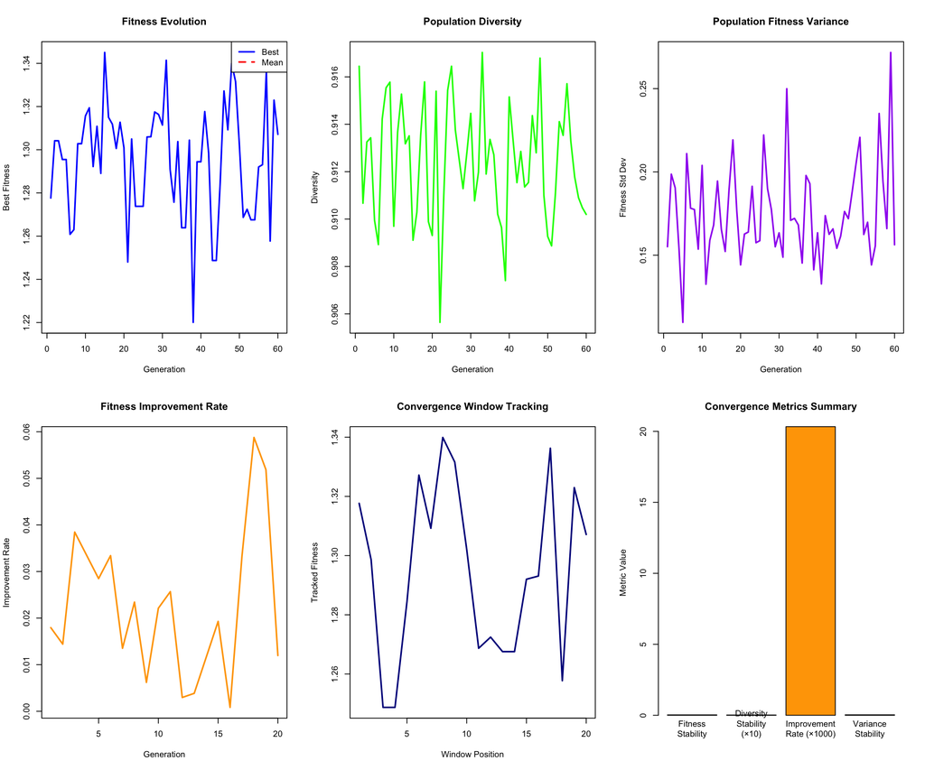

```r
# Create detailed diagnostic plots
par(mfrow = c(2, 3))

# Plot fitness evolution with convergence window
fitness_hist <- ga_diagnostic$fitness_history
plot(1:nrow(fitness_hist), fitness_hist[, "best"],
     type = "l", col = "blue", lwd = 2,
     xlab = "Generation", ylab = "Best Fitness",
     main = "Fitness Evolution")
lines(1:nrow(fitness_hist), fitness_hist[, "mean"], col = "red", lty = 2)
legend("topright", legend = c("Best", "Mean"), col = c("blue", "red"),
       lty = c(1, 2), lwd = 2)
grid(TRUE)

# Plot population diversity
diversity_hist <- sapply(ga_diagnostic$population_stats, function(x) x$diversity)
plot(1:length(diversity_hist), diversity_hist,
     type = "l", col = "green", lwd = 2,
     xlab = "Generation", ylab = "Diversity",
     main = "Population Diversity")
grid(TRUE)

# Plot fitness variance
variance_hist <- sapply(ga_diagnostic$population_stats, function(x) x$fitness_std)
plot(1:length(variance_hist), variance_hist,
     type = "l", col = "purple", lwd = 2,
     xlab = "Generation", ylab = "Fitness Std Dev",
     main = "Population Fitness Variance")
grid(TRUE)

# Plot improvement rate (if available from convergence history)
if (!is.null(ga_diagnostic$convergence_history$improvement_rate)) {
  improvement_data <- ga_diagnostic$convergence_history$improvement_rate
  valid_indices <- which(!is.na(improvement_data) & improvement_data > 0)
  if (length(valid_indices) > 1) {
    plot(valid_indices, improvement_data[valid_indices],
         type = "l", col = "orange", lwd = 2,
         xlab = "Generation", ylab = "Improvement Rate",
         main = "Fitness Improvement Rate")
    grid(TRUE)
  } else {
    # Create placeholder plot if no valid improvement data
    plot(1:10, rep(0, 10), type = "n",
         xlab = "Generation", ylab = "Improvement Rate",
         main = "Fitness Improvement Rate\n(No valid data)")
    text(5, 0, "No improvement data available", cex = 1.2)
  }
} else {
  # Create placeholder plot if improvement data not available
  plot(1:10, rep(0, 10), type = "n",
       xlab = "Generation", ylab = "Improvement Rate",
       main = "Fitness Improvement Rate\n(Not available)")
  text(5, 0, "Improvement rate tracking not available", cex = 1.2)
}

# Plot convergence criteria status over time
conv_hist <- ga_diagnostic$convergence_history
if (!is.null(conv_hist$fitness) && length(conv_hist$fitness) > 0) {
  valid_fit <- which(!is.na(conv_hist$fitness) & is.finite(conv_hist$fitness))
  if (length(valid_fit) > 1) {
    plot(valid_fit, conv_hist$fitness[valid_fit],
         type = "l", col = "darkblue", lwd = 2,
         xlab = "Window Position", ylab = "Tracked Fitness",
         main = "Convergence Window Tracking")
    grid(TRUE)
  } else {
    # Create placeholder plot if insufficient valid data
    plot(1:10, rep(0, 10), type = "n",
         xlab = "Window Position", ylab = "Tracked Fitness",
         main = "Convergence Window Tracking\n(Insufficient data)")
    text(5, 0, "Not enough convergence data", cex = 1.2)
  }
} else {
  # Create placeholder plot if no convergence data
  plot(1:10, rep(0, 10), type = "n",
       xlab = "Window Position", ylab = "Tracked Fitness",
       main = "Convergence Window Tracking\n(No data)")
  text(5, 0, "Convergence tracking not available", cex = 1.2)
}

# Summary statistics plot
# Ensure all metrics are finite and replace any problematic values
fitness_stab <- ifelse(is.finite(diags$metrics$fitness_stability), diags$metrics$fitness_stability, 0)
diversity_stab <- ifelse(is.finite(diags$metrics$diversity_stability), diags$metrics$diversity_stability * 10, 0)
improvement_rate <- ifelse(is.finite(diags$metrics$mean_improvement_rate), diags$metrics$mean_improvement_rate * 1000, 0)
variance_stab <- ifelse(is.finite(diags$metrics$variance_stability), diags$metrics$variance_stability, 0)

barplot(c(fitness_stab, diversity_stab, improvement_rate, variance_stab),
        names.arg = c("Fitness\nStability", "Diversity\nStability\n(×10)",
                     "Improvement\nRate (×1000)", "Variance\nStability"),
        col = c("blue", "green", "orange", "purple"),
        main = "Convergence Metrics Summary",
        ylab = "Metric Value")
```

```r
par(mfrow = c(1, 1))
```